# Vignettes

CheonGeunChoi

2023-03-01

# 1. A Quick Overview(비네트 고정법)

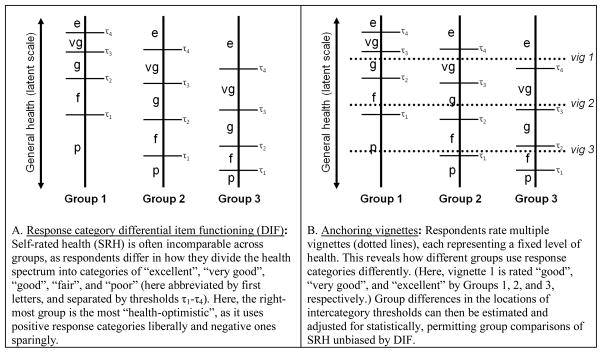

Fig

This section assumes that you have already have anchors installed and want a quick introduction/overview. Information on installation, background, and examples of anchors are provide in detail in subsequent sections. All examples and objects described in this document assume that you have loaded the package in an R session,

```r
# install.packages("anchors_3.0-8.tar.gz", repos = NULL, type = "source")
library(anchors)
```

A list of the functions and datasets with help pages can be found using,

```r
help(package="anchors")
```

For a list of demonstrations of functions, uses of data, and replications of published results,

```r
demo(package="anchors")
```

The function anchors() has two method= options

- B non-parametric rank method from Wand (2007a)
- C non-parametric rank method from King et al. (2004) and King and Wand (2007)
- There are two other key supporting functions that will be discussed in turn: anchors.order() and chopit()

For methods B and C, one can also specify that all combinations of subsets of vignettes (but retaining the same relative order as submitted in the formula) be analyzed using the option anchors(…, combn=TRUE). The default is combn=FALSE since for more than three vignettes, the process requires non-trivial computational time. Details can be found in the later section on vignette selection, and via help(anchors.combn).

Datasets with anchoring vignettes that are made available by the anchors package include

- chopitsim Simulated Data for test chopit function
- mexchn China-Mexico political efficacy data
- poleff Simulated Political Efficacy Data
- poleffna Simulated Political Efficacy Data with NA (demo only, don’t use)
- freedom Individual freedom of speech data
- sleep Sleep data for china
- selfcare Self-care data for china
- table1 Reference from Table 1 of King and Wand (2007)
- table1src Specific response values that have inequalities to create table1

Any of these can be loaded with data(), for example,

```r
data(freedom)
```

Survey respondents were asked in almost the same language for a self-assessment and for an assessment of several hypothetical persons described by written vignettes. The self assessment (self, in the data set), “How free do you think [name/you] [is/are] to express [him-her/your]self without fear of government reprisal?” was first asked of the survey respondent with respect to him or herself, and then after each of vignette. The possible response categories are:

- 1Completely free
- 2Very free
- 3Moderately free
- 4Slightly free
- 5Not free at all

The vignettes, ordered from most free to least free, are:

- vign1[Kay] does not like many of the government’s policies. She frequently publishes her opinion in newspapers, criticizing decisions by officials and calling for change. She sees little reason these actions could lead to government reprisal.
- vign2[Michael] disagrees with many of the government’s policies. Though he knows criticism is frowned upon, he doesn’t believe the government would punish someone for expressing critical views. He makes his opinion known on most issues without regard to who is listening.
- vign3[Bob] has political views at odds with the government. He has heard of people occasionally being arrested for speaking out against the government, and government leaders sometimes make political speeches condemning those who criticize. He sometimes writes letters to newspapers about politics, but he is careful not to use his real name.
- vign4[Connie] does not like the government’s stance on many issues. She has a friend who was arrested for being too openly critical of governmental leaders, and so she avoids voicing her opinions in public places.
- vign5[Vito] disagrees with many of the government’s policies, and is very careful about whom he says this to, reserving his real opinions for family and close friends only. He knows several men who have been taken away by government officials for saying negative things in public.
- vign6[Sonny] lives in fear of being harassed for his political views. Everyone he knows who has spoken out against the government has been arrested or taken away. He never says a word about anything the government does, not even when he is at home alone with his family.

Demonstration files are available, both to provide examples of the use of functions and as an aid to those who would simply like to re-compute published results that have used versions of the anchors package, anchors.plot Demo of plotting with anchors

- chopit Demo of chopit: summary, plot
- anchors.freedom Wand et al (2007) rank analysis of freedom
- anchors.freedom3 Wand et al (2007) Figure 2 histogram with 3 vignettes
- anchors.freedom6 Wand et al (2007) Figure 1 histogram with 6 vignettes
- anchors.vign2 King and Wand (2007) Table 1 anchors()
- anchors.mexchn King and Wand (2007) Figure 1 histogram
- entropy.mexchn King and Wand (2007) Figure 2 entropy()
- entropy.sleep King and Wand (2007) Figure 3 entropy()
- entropy.self King and Wand (2007) Figure 4 entropy()
- anchors.mexchn2 Repl King et al (2004) Figure 2
- chopit.mexchn King et al (2004) Table 2 (non-linear taus)

Any of these can be invoked with demo(), for example,

```r
demo(anchors.freedom)
```

```
##
##
##  demo(anchors.freedom)
##  ---- ~~~~~~~~~~~~~~~
##
## > #######################################################################
## > ##
## > ## Author:    Jonathan Wand <wand(at)stanford.edu>
## > ## Created:   2007-02-01
## > ##
## > ## Modified
## > ## - 2008-05-09 : JW
## > ##   anchors 3.0 syntax
## > ##
## > #######################################################################
## > cat("Replication of Wand et al 2007 rank analysis of freedom data\n")
## Replication of Wand et al 2007 rank analysis of freedom data
##
## > data(freedom)
##
## > ## ordering of vignettes
## > z1 <- anchors.order( ~ vign1+vign2+vign3+vign4+vign5+vign6, data=freedom)
##
## > summary(z1,top=10,digits=2)
## ANCHORS: SUMMARY OF VIGNETTE ORDERING
##
## Treatment of ties: represent as sets
##
## Number of cases with at least two distinct vignette responses: 3267
## and with no violations of natural ordering: 773
## and with no more than 1 violation of natural ordering: 1654
## and with no more than 2 violation of natural ordering: 2299
##
## Proportion of cases a vignette (row) is less than another (column):
##     <1   <2   <3   <4   <5   <6
## 1   NA 0.24 0.65 0.76 0.72 0.77
## 2 0.32   NA 0.66 0.73 0.71 0.75
## 3 0.08 0.12   NA 0.46 0.36 0.57
## 4 0.06 0.08 0.14   NA 0.18 0.37
## 5 0.07 0.07 0.20 0.34   NA 0.49
```

[output cut: 437 more lines]

```
## 0.261 0.185 0.275 0.172 0.107
##
## Allocating cases to their MinEnt values produces
##     1     2     3     4     5
## 0.256 0.164 0.322 0.153 0.105
##
## > tb <- xtabs( ~ self, freedom, subset=country=="Eastasia"); tb/sum(tb)
## self
##          1          2          3          4          5
## 0.07319778 0.10905730 0.21922366 0.31016636 0.28835490
##
## > tb <- xtabs( ~ self, freedom, subset=country=="Oceania");   tb/sum(tb)
## self
##         1         2         3         4         5
## 0.1510673 0.2512315 0.2446634 0.1986864 0.1543514
```

# 2. Introduction fo Anchoring Vignettes

## 2.1. 개념

- 비네트 고정법(anchoring vignette)은 응답자의 응답 편파(혹은 응답 편향, response bias)를 보정하기 위해서 King et al.(2004) 등에 의해 제안되었다. Likert형 측정문항에서 응답자는 개인의 속성에 따라서 문항 및 척도를 다르게 해석(혹은 이해)하여 응답할 수 있는데(김은나, 2015; Chevalier & Fielding, 2011), 비네트 고정법은 이러한 해석(혹은 이해)에 따른 응답의 차이를 보정하기 위한 기법 중 하나이다.
- 비네트 고정법에서는 측정 변인(예, 학습 동기)에 대한 전형적인 하/중/상 수준의 사례에 대한 응답자의 반응을 활용하여, 해당 변인과 관련된 측정문항에 대한 응답자의 응답 편파를 보정한다. 예컨대, [그림 1]은 학생들의 학습동기를 5개의 문항으로 측정할 때에 응답자들의 응답 편파를 보정하기 위해 제작된 하/중/상 수준의 비네트 문항들을 제시하고 있다(von Davier et al., 2018).

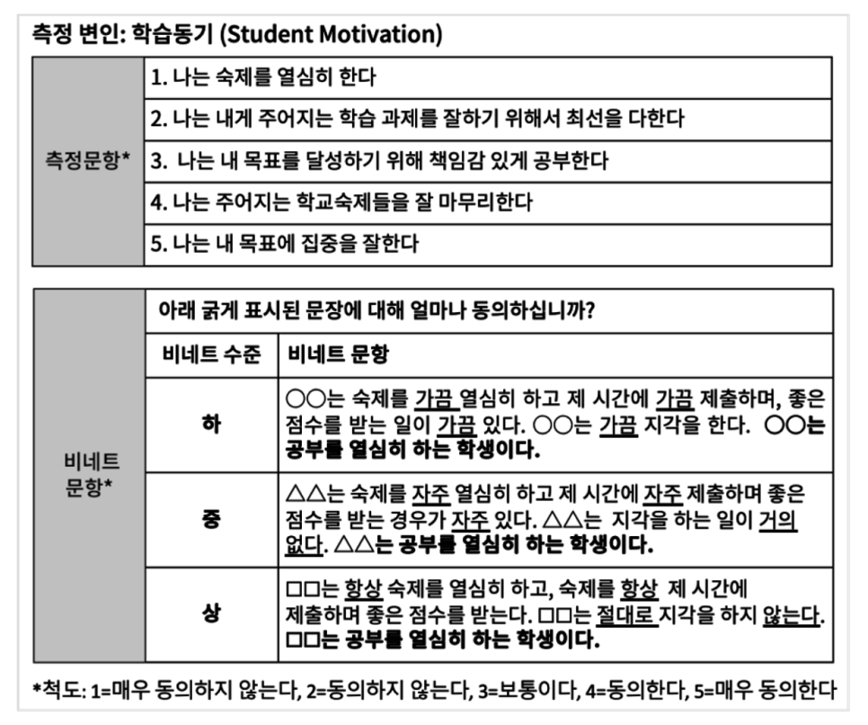

Fig4

[그림1] ’학습동기’에 대한 비네트 문항 예시

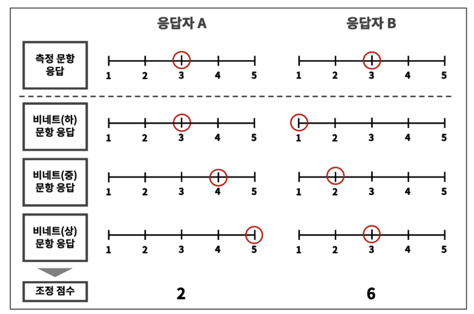

Fig5

[그림 2] 비네트 고정법을 활용한 응답자 점수 비교 예시

비네트 고정법이 적절하게 활용되려면 다음과 같은 가정을 만족시켜야 한다(King et al., 2004). 첫 번째 가정은 ’응답 일관성(response consistency)’이며, 이는 응답자들이 측정문항과 비네트 문항에서 동일한 평가 기준을 적용하여 일관되게 응답해야 한다는 것이다. 두 번째 가정은 ’비네트 동일성(vignette equivalence)’이며, 이는 모든 응답자들이 비네트 문항에 제시된 사례들에 대하여 특정 측정 변인에 관련한 사례로 동일하게 해석(혹은 이해)해야 한다는 것이다. 예컨대, 위 그림의 예시에서 응답자들은 비네트 문항들이 ’학습동기’와 관련한 사례라고 공통적으로 해석해야 한다.

Consider a survey question along with response categories that is asked as a self-assessment,

- How free do you think you are to express yourself without fear of government reprisal? (1) Completely Free, (2) Very Free, (3) Moderately Free, (4) Slightly Free, (5) Not Free at All

One key difficulty of analyzing the results from such a survey question is the possibility that individuals apply different standards in the selection of a response category. Researchers have tried to ameliorate the problems of interpersonal and cross-cultural incomparability in survey research with careful question wording, translation (and back translation), focus groups, cognitive debriefing, and other techniques, most of which are designed to improve the survey question. In contrast, anchoring vignettes is a technique that seeks to bring additional data to bear on the problem.

For example, vignettes corresponding to the above political freedom question attempt to describe hypothetical individuals who have different levels of freedom from government reprisal. The following six vignettes are intended to correspond to distinct levels of political freedom in order of decreasing freedom,

- vign1[Kay] does not like many of the government’s policies. She frequently publishes her opinion in newspapers, criticizing decisions by officials and calling for change. She sees little reason these actions could lead to government reprisal.
- vign2[Michael] disagrees with many of the government’s policies. Though he knows criticism is frowned upon, he doesn’t believe the government would punish someone for expressing critical views. He makes his opinion known on most issues without regard to who is listening.
- vign3[Bob] has political views at odds with the government. He has heard of people occasionally being arrested for speaking out against the government, and government leaders sometimes make political speeches condemning those who criticize. He sometimes writes letters to newspapers about politics, but he is careful not to use his real name.
- vign4[Connie] does not like the government’s stance on many issues. She has a friend who was arrested for being too openly critical of governmental leaders, and so she avoids voicing her opinions in public places.
- vign5[Vito] disagrees with many of the government’s policies, and is very careful about whom he says this to, reserving his real opinions for family and close friends only. He knows several men who have been taken away by government officials for saying negative things in public.
- vign6[Sonny] lives in fear of being harassed for his political views. Everyone he knows who has spoken out against the government has been arrested or taken away. He never says a word about anything the government does, not even when he is at home alone with his family.

After each of these vignettes, a corresponding evaluation question is asked with the same response categories as for the self-assessment.

- How free do you think [name] is to express [him/her]self without fear of government reprisal? (1) Completely Free, (2) Very Free,
3. Moderately Free, (4) Slightly Free, (5) Not Free at All
- Note: In the case where there are missing values for responses to the self-assessment or the vignettes, it is important that these be coded as ‘0’ (zero), instead of NA or some other missing value if you wish to retain the other (non-missing) responses of an individual in the parametric model to be described shortly (see chopit). For all non-parametric analysis that rely on anchors or anchors.order, cases with missing responses (either NA or zero) must be listwise deleted. We pro- vide a handy function, replace.value, that facilitates the alteration of the coding of missing values for subsets of variables.

# 3. Indexing Notation

Our notation is a generalization of King et al. designed to accommodate our enhancements to the various models. We index survey questions, response categories, and respondents as follows:

- We index survey questions by the pair ($s; j$), where question set $s (s =1, ..., S)$ corresponds to the self-assessment question number and refers to the set of questions that includes the self-assessment question (indicated by $j = 0$) and, optionally, one or more vignette questions (indicated by $j = 1, ..., J_s$).
- We index response categories by $k (k = 1,..., K_s$) separately for each survey question since they can each have different response categories. Each set of questions (self-assessment and vignettes) must have the same number of choice categories (coded as increasing sequential integers starting with 1). Missing values (whether structural, because the question was not asked, or due to nonresponse) should be coded as k = 0.
- We index respondents by $i$ or $l$. Respondent $i(i = 1, ..., n)$ is asked all of the self-assessment questions. Respondent $l(l = 1, ..., N)$ is asked all of the vignette questions. (Respondents are indexed for self-assessment and vignette questions separately since each could be asked of independent samples; if they are asked of the same individuals, then $i = l$ and $n = N$.) If your survey design asks each set of vignette questions in separate samples (and separate from the self-assessment question), then index each set of vignettes according to unique values of $l$ and use the missing value code (k = 0) for vignettes that are not asked of a subgroup; in other words, stack the data in block diagonal format.

Thus, every mathematical symbol in the model could be indexed by $s, j, k$, and either $i$ or $l$. In practice, we drop indexes that are constant.

# 4. A Nonparametric Approach(조정점수 산출방법)

## 4.1. Definition

Define $C_{is}$ as the self-assessment relative to the corresponding set of vignettes. Let $y_i$ be the self-assessment response and $z_{i1}, ..., z_{iJ}$ be the J vignette responses, for the $i$th respondent. For respondents with consistently ordered rankings on all vignettes ($z_{j-1} < z_j$ , for $j = 2,..., J$), we create the DIF-corrected self-assessment $C_i$

$$C_{i} =
\begin{pmatrix}
1 & \quad \text{if} \quad y_i < z_{i1} \quad \quad\quad \\
2 & \quad \text{if} \quad y_i = z_{i1} \quad \quad \quad \\
3 & \quad \text{if} \quad z_{i1} < y_i < z_{i2}\quad \\
\vdots & \vdots \\
2J + 1& \quad \text{if} \quad y_i > z_{iJ} \quad \quad\quad
\end{pmatrix}$$

Respondents who give tied or inconsistently ordered vignette responses may have an interval values of C, if the tie/inconsistency results in multiple conditions in equation 1 appearing to be true. A more general definition of C is defined as the minimum to maximum values among all the conditions that hold true in equation 1. Values of C that are intervals, rather than scalar, represent the set of inequalities over which the analyst cannot distinguish without further assumption.

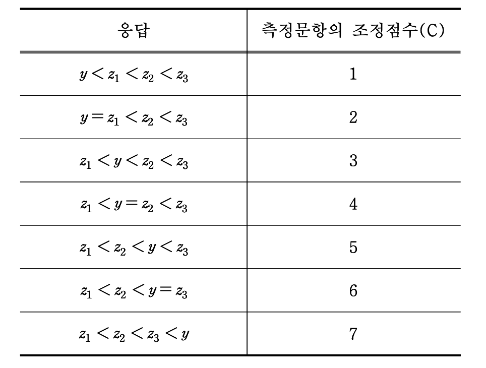

Fig3

## 4.2. Example Code: anchors().

This example again first loads the library and example dataset, and then anchors() calculates C for each individual. In the non-parametric estimation, only one self-question and corresponding set of vignettes are analyzed at a time.

```r
summary(freedom)
```

```
##       sex              age             educ           country
##  Min.   :0.0000   Min.   : 0.00   Min.   :1.000   Eastasia:2705
##  1st Qu.:0.0000   1st Qu.:26.75   1st Qu.:1.000   Eurasia : 186
##  Median :1.0000   Median :37.00   Median :3.000   Oceania : 609
##  Mean   :0.5669   Mean   :40.16   Mean   :3.029
##  3rd Qu.:1.0000   3rd Qu.:51.00   3rd Qu.:4.000
##  Max.   :1.0000   Max.   :97.00   Max.   :7.000
##  NA's   :4        NA's   :20      NA's   :30
##       self           vign1           vign2          vign3           vign4
##  Min.   :1.000   Min.   :1.000   Min.   :1.00   Min.   :1.000   Min.   :1.000
##  1st Qu.:3.000   1st Qu.:2.000   1st Qu.:1.00   1st Qu.:3.000   1st Qu.:4.000
##  Median :4.000   Median :2.000   Median :2.00   Median :4.000   Median :4.000
##  Mean   :3.535   Mean   :2.508   Mean   :2.41   Mean   :3.628   Mean   :4.089
##  3rd Qu.:5.000   3rd Qu.:3.000   3rd Qu.:3.00   3rd Qu.:4.000   3rd Qu.:5.000
##  Max.   :5.000   Max.   :5.000   Max.   :5.00   Max.   :5.000   Max.   :5.000
##
##      vign5           vign6
##  Min.   :1.000   Min.   :1.000
##  1st Qu.:3.000   1st Qu.:4.000
##  Median :4.000   Median :5.000
##  Mean   :3.877   Mean   :4.427
##  3rd Qu.:5.000   3rd Qu.:5.000
##  Max.   :5.000   Max.   :5.000
##
```

```r
a1 <- anchors(self ~ vign2+vign3+vign4+vign5+vign6, freedom, method="C")
summary(a1)
```

```
##
## ANCHORS: SUMMARY OF RELATIVE RANK ANALYSIS:
##
## Overview of C-ranks
##
## Number of cases: 1763 with interval value, 1737 with scalar value
##
## Maximum possible C-rank value: 11
##
## Interval on C-scale: Frequency and proportions Cs to Ce
##            N  Prop MinEnt
##  1 to  1 387 0.111      1
##  2 to  2 279 0.080      2
##  3 to  3 336 0.096      3
##  4 to  4  81 0.023      4
##  5 to  5  59 0.017      5
##  6 to  6  28 0.008      6
##  7 to  7  11 0.003      7
##  8 to  8  31 0.009      8
##  9 to  9  22 0.006      9
## 10 to 10 164 0.047     10
## 11 to 11 339 0.097     11
##  1 to  4  16 0.005      1
##  1 to  5  12 0.003      1
##  1 to  6  25 0.007      6
##  1 to  7   5 0.001      6
##  1 to  8  31 0.009      6
##  1 to  9   5 0.001      6
##  1 to 10  32 0.009      6
##  1 to 11  19 0.005      6
##  2 to  4  15 0.004      3
##  2 to  5  11 0.003      3
##  2 to  6  22 0.006      6
##  2 to  7   4 0.001      6
##  2 to  8  51 0.015      6
##  2 to  9  19 0.005      6
##  2 to 10 177 0.051      6
##  2 to 11  91 0.026      6
##  3 to  6  31 0.009      6
##  3 to  7   3 0.001      6
```

[output cut: 28 more lines]

```
##      1     2     3     4     5     6     7     8     9    10    11
##  0.223 0.161 0.193 0.047 0.034 0.016 0.006 0.018 0.013 0.094 0.195
##
## Distribution of ranks allocating interval cases uniformly
##      1   2     3    4    5    6     7     8    9   10    11
##  0.116 0.1 0.125 0.07 0.07 0.09 0.079 0.091 0.06 0.09 0.107
##
## Distribution of ranks allocating interval cases via cpolr
## and conditioning on observed ranks
##     1     2     3     4     5     6     7     8     9    10    11
## 0.118 0.103 0.142 0.051 0.045 0.138 0.025 0.155 0.017 0.095 0.110
##
## Allocating cases to their MinEnt values produces
##     1     2     3     4     5     6     7     8     9    10    11
## 0.119 0.080 0.103 0.023 0.017 0.472 0.003 0.009 0.006 0.060 0.108
```

The names of vignettes must be passed to the function in the same order as the direction of the responses. In the example, vign2 is in the same (highest) direction as the response category 1, while the vign6 is in the same direction (lowest) as the response category 5. (We drop vign1 here for space reason when printing the summary-with the different combinations of intervals of C can be numerous.)

- If anchors produces many ties you should check that you passed the vignettes in the correct order, but we also offer a function that investigates the ordering of vignettes in detail.

## 4.3. Example Code: anchors.order().

The function anchors.order(), and the associated methods summary.anchors.order and barplot.anchors.order investigate the relationship between vignette responses without reference to the self- assessment question.

```r
vo1<-anchors.order(~vign2+vign3+vign4+vign5+vign6, freedom)
summary(vo1,top=10,digits=3)
```

```
## ANCHORS: SUMMARY OF VIGNETTE ORDERING
##
## Treatment of ties: represent as sets
##
## Number of cases with at least two distinct vignette responses: 3223
## and with no violations of natural ordering: 1178
## and with no more than 1 violation of natural ordering: 1959
## and with no more than 2 violation of natural ordering: 2621
##
## Proportion of cases a vignette (row) is less than another (column):
##      <1    <2    <3    <4    <5
## 1    NA 0.663 0.732 0.707 0.754
## 2 0.121    NA 0.457 0.363 0.575
## 3 0.080 0.138    NA 0.183 0.374
## 4 0.068 0.198 0.339    NA 0.495
## 5 0.070 0.081 0.100 0.103    NA
##
## Upper tri =     p_{ij} - p_{ji} (negative values suggest misorderings)
## Lower tri = 1 - p_{ij} - p_{ji} (big numbers means many ties)
##       1     2     3      4     5
## 1    NA 0.542 0.652  0.639 0.684
## 2 0.215    NA 0.320  0.165 0.494
## 3 0.188 0.440    NA -0.156 0.275
## 4 0.405 0.477 0.345     NA 0.392
## 5 0.225 0.176 0.526  0.402    NA
##
## Top 10 orderings (out of 262 unique orderings):
##
##               Frequency Proportion Ndistinct Nviolation
## 1,{2,3,4,5}         309     0.0883         2          0
## {1,2,3,4,5}         277     0.0791         1          0
## 1,2,{3,4,5}         221     0.0631         3          0
## 1,{2,4},{3,5}       212     0.0606         3          1
## 1,2,{3,4},5         178     0.0509         4          0
## 1,{2,3,4},5         177     0.0506         3          0
## 1,4,{2,3,5}         157     0.0449         3          2
## 1,2,4,{3,5}         106     0.0303         4          1
## 1,{2,4},3,5          96     0.0274         4          1
## 1,4,2,{3,5}          73     0.0209         4          2
```

Also in the fourth row, we also have Nviolation = 1 because in these cases the 4th vignette has a value less than the 3th vignette. The column Nviolation is calculated by the number of times any of the vignette responses are strictly contrary to the natural ordering, as given by the user’s formula (ordered left to right).

In this list of vignette response rankings the careful observer might note that ties and order violations occur one pair of vignettes, between vign3 and vign4. The summary() function seeks to make it easier than staring at this list to identify troublesome patterns by providing two additional summary statistics.

There is an issue in the political freedom data with the ordering between vign3 and vign4. Reasonable people might disagree (and apparently the respondents do) about which scenario indicates less freedom: Bob writes letters to newspapers about politics using a pseudonym, while Michael makes his opinion known on most issues without regard to who is listening. For some respondents the mere existence of a media outlet such as a paper to which one could write a letter discussing political subjects may be the more important indicator of freedom than the ability to talk publicly about politics. The substance of the Sonny and Vito vignettes seem to be correctly ordered, but perhaps the reversal is due to whether or not the vignette ends with the statement about men being taken away for speaking out against the government. Further indicating that vign4 describes a more repressive scenario, it is more often tied with the most extreme vign6 than any other vignette.

Above this matrix is a matrix the number of times that reversals in responses occur as matrix of pairwise comparison between vignettes. Each cell summarizes the proportion of cases that the vignette listed at the beginning of the row i has a response less than the vignette listed in column $j$. Let $p_{ij}$ be the value in cell $(i, j)$, then $1 - p_{ij} - p_{ji}$ is the number of cases where vignette i and vignette $j$ have the same value. For example, the proportion of cases where vign3<vign4 is 0.183, while the proportion of cases where vign4<vign3 is 0.339. Since $p_{34} < p_{43}$ there appears to be an inconsistency of the expert ordering.

The analysis of vignettes is useful both at the stage of evaluating a pilot study of survey instruments, as well at the stage of choosing how (and whether) to use particular vignettes. The results of non-parametric anchoring vignettes analysis using C are entirely dependent on which vignettes are included and the order in which they are specified.

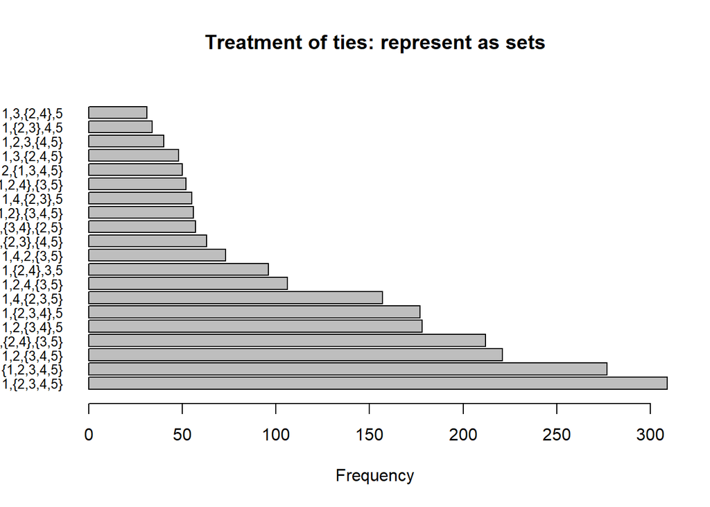

```r
barplot(vo1)
```

In light of this it is worth reestimating C using the consensus ordering of the vignettes,

```r
a2 <- anchors(self ~ vign2+vign3+vign5+vign4+vign6, freedom, method="C")
summary(a2)
```

```
##
## ANCHORS: SUMMARY OF RELATIVE RANK ANALYSIS:
##
## Overview of C-ranks
##
## Number of cases: 1654 with interval value, 1846 with scalar value
##
## Maximum possible C-rank value: 11
##
## Interval on C-scale: Frequency and proportions Cs to Ce
##            N  Prop MinEnt
##  1 to  1 387 0.111      1
##  2 to  2 279 0.080      2
##  3 to  3 336 0.096      3
##  4 to  4  81 0.023      4
##  5 to  5  59 0.017      5
##  6 to  6  80 0.023      6
##  7 to  7  38 0.011      7
##  8 to  8  61 0.017      8
##  9 to  9  22 0.006      9
## 10 to 10 164 0.047     10
## 11 to 11 339 0.097     11
##  1 to  4  16 0.005      1
##  1 to  5  12 0.003      1
##  1 to  6  20 0.006      6
##  1 to  7   1 0.000      6
##  1 to  8  39 0.011      6
##  1 to  9   6 0.002      6
##  1 to 10  32 0.009      6
##  1 to 11  19 0.005      6
##  2 to  4  15 0.004      3
##  2 to  5  11 0.003      3
##  2 to  6  31 0.009      6
##  2 to  7   6 0.002      6
##  2 to  8  51 0.015      6
##  2 to  9   8 0.002      6
##  2 to 10 177 0.051      6
##  2 to 11  91 0.026      6
##  3 to  6  63 0.018      6
##  3 to  7  19 0.005      6
```

[output cut: 28 more lines]

```
##     1     2     3     4     5     6     7     8     9    10    11
##  0.21 0.151 0.182 0.044 0.032 0.043 0.021 0.033 0.012 0.089 0.184
##
## Distribution of ranks allocating interval cases uniformly
##      1   2     3     4     5     6     7    8     9    10    11
##  0.116 0.1 0.127 0.073 0.068 0.096 0.072 0.09 0.057 0.093 0.107
##
## Distribution of ranks allocating interval cases via cpolr
## and conditioning on observed ranks
##     1     2     3     4     5     6     7     8     9    10    11
## 0.118 0.103 0.144 0.056 0.042 0.147 0.037 0.120 0.016 0.107 0.110
##
## Allocating cases to their MinEnt values produces
##     1     2     3     4     5     6     7     8     9    10    11
## 0.119 0.080 0.103 0.023 0.017 0.431 0.011 0.017 0.006 0.084 0.109
```

The analysis of vignettes is useful both at the stage of evaluating a pilot study of survey instruments, as well at the stage of choosing how (and whether) to use particular vignettes. The results of non-parametric anchoring vignettes analysis using C are entirely dependent on which vignettes are included and the order in which they are specified.

## 4.4. Relative ranks: calculations, vignette selection, and plotting

After the researcher has deduced or confirmed the order of vignettes, the calculation of C using the function anchors() uses a similar syntax but with the additional designation of the self-assessment variable on the right hand side. In this example, the self-assessment variable is aptly named self, and C is calculated by,

```r
a2 <- anchors(self ~ vign2+vign3+vign5+vign4+vign6, freedom, method="C", combn = TRUE)

summary(a2)
```

```
##
## ANCHORS: SUMMARY OF RELATIVE RANK ANALYSIS:
##
## Overview of C-ranks
##
## Number of cases: 1654 with interval value, 1846 with scalar value
##
## Maximum possible C-rank value: 11
##
## Interval on C-scale: Frequency and proportions Cs to Ce
##            N  Prop MinEnt
##  1 to  1 387 0.111      1
##  2 to  2 279 0.080      2
##  3 to  3 336 0.096      3
##  4 to  4  81 0.023      4
```

[output cut: 135 more lines]

Note that anchors() function again assumes that the vignettes are entered into formula in ascending order from left to right.

The summary of the frequencies of the scalar and interval values of C can be rather extensive. The row names Cs to Ce indicate the interval of C; if Cs = Ce then C is a scalar. The columns N and Prop are the frequency and proportion of the cases, respectively.

In all approaches the predictions of scalar valued observations are fixed at their observed values, independent of the assumptions of each model. Predictions of vector valued observations are restricted to within their observed range, also with certainty and independent of modeling choices. Thus the more scalar values, the less the assumptions of a particular approach will affect the histogram. Similarly, the narrower the intervals of non-scalar values, the less assumptions matter as well.

The choice of methods will depend on whether one wants to assume a particular allocation method to make a particular argument (e.g., a worst case scenario) , or whether one would like to believe in a parametric model.

## 4.4. Example Code: Subsets of vignettes.

Calculating entropy for subsets of vignettes as suggested byWand and King (2007) is straightforward. The anchors(,combn=TRUE) calculates statistics of interest, including entropy measures, for every ordered combination of vignettes. For more details, please see help(anchors.combn) in R and King and Wand (2007).

The function with the addition of the option anchors(, combn=TRUE) looks at all combinations of subsets of vignettes and calculates the minimum entropy and (optionally) the entropy based on estimated values of a censored ordered probit model. The function also summarizes how many interval valued C are present for a particular subset of vignettes.

```r
data(freedom)
fo <- list(self = self ~ 1,
 vign = cbind(vign1,vign3,vign6) ~ 1,
 cpolr= ~ as.factor(country) + sex + age + educ)
ent <- anchors(fo, data = freedom, method="C", combn=TRUE)
summary(ent,digits=3)
```

```
##
## ANCHORS: SUMMARY OF RELATIVE RANK ANALYSIS:
##
## Overview of C-ranks
##
## Number of cases: 522 with interval value, 2925 with scalar value
##
## Maximum possible C-rank value: 7
##
## Interval on C-scale: Frequency and proportions Cs to Ce
##            N  Prop MinEnt
##  1 to  1 496 0.144      1
##  2 to  2 225 0.065      2
##  3 to  3 492 0.143      3
##  4 to  4 236 0.068      4
##  5 to  5 497 0.144      5
##  6 to  6 489 0.142      6
##  7 to  7 490 0.142      7
##  1 to  4  22 0.006      3
##  1 to  5   1 0.000      5
##  1 to  6  28 0.008      5
##  1 to  7  12 0.003      5
##  2 to  4  39 0.011      3
##  2 to  5  10 0.003      5
##  2 to  6 124 0.036      5
##  2 to  7  31 0.009      5
##  3 to  6   9 0.003      5
##  3 to  7   9 0.003      5
##  4 to  6 193 0.056      5
##  4 to  7  44 0.013      5
##
## Note: MinEnt is the rank for the interval that minimizes entropy
##
## Summary of C-ranks with ties/intervals broken:
##
## Distribution of ranks omiting interval cases
##     1     2     3     4    5     6     7
##  0.17 0.077 0.168 0.081 0.17 0.167 0.168
##
## Distribution of ranks allocating interval cases uniformly
```

[output cut: 15 more lines]

```
## 1       123             1.903           1.844            522     1.471
## 4        12             1.450           1.430            220     1.151
## 3        13             1.490           1.465            195     1.137
## 2        23             1.527           1.489            418     1.285
## 7         1             0.795           0.795              0     1.000
## 6         3             0.959           0.959              0     1.000
## 5         2             1.044           1.044              0     1.000
##   Max. rank
## 1         7
## 4         5
## 3         5
## 2         5
## 7         3
## 6         3
## 5         3
```

### Subsetting and plotting

Since C is defined for each case only relative to an individual’s own responses, it is sometimes useful to do the analysis separately for each region.

```r
fo <- list(self = self ~ 1, vign = cbind(vign1,vign3, vign6) ~ 1, cpolr = ~sex + age + educ)

a1e <- anchors(fo, freedom, method = "C", subset = country == "Eastasia")
a1o <- anchors(fo, freedom, method = "C", subset = country == "Oceania")
```

The barplot() method for anchors.rank objects plots the (average) fitted proportions for each value of C. As many anchors.rank objects can be passed to barplot(), and the fitted proportions from each object will be placed beside each other, in the order given. To produce Figure 2, we invoke:

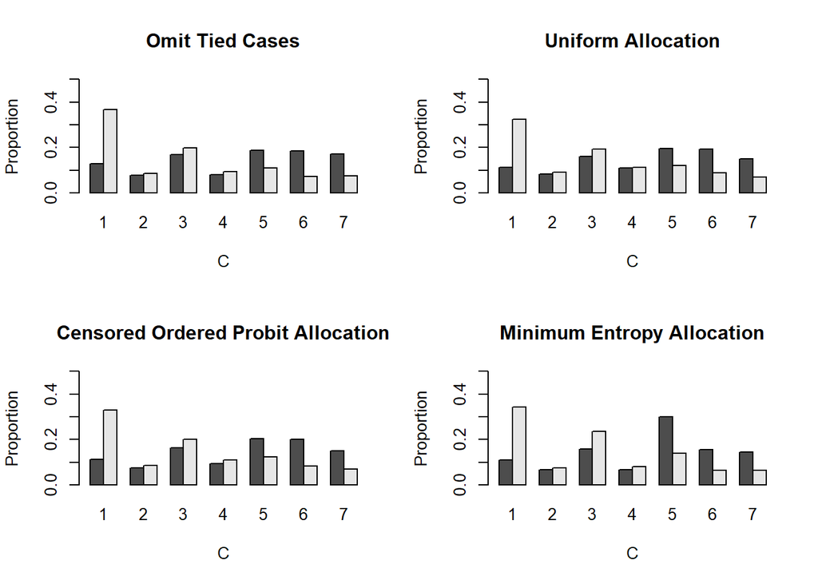

```r
par(mfrow = c(2, 2))
ylim <- c(0, 0.5)
barplot(a1e, a1o, ties = "omit", ylim = ylim, main = "Omit Tied Cases")
barplot(a1e, a1o, ties = "uniform", ylim = ylim, main = "Uniform Allocation")
barplot(a1e, a1o, ties = "cpolr", ylim = ylim, main = "Censored Ordered Probit Allocation")
barplot(a1e, a1o, ties = "minentropy", ylim = ylim, main = "Minimum Entropy Allocation")
```

One important feature to be noted about including cpolr= variables is that cases with any missing value in the covariates will be listwise deleted for both both the estimated and minimum entropy calculations to ensure a common basis for comparisons. As such, the minimum entropy values may change as a function of what variables (if any) are included in cpolr=.

The plot() method is described in help(plot.anchors.rank), and an example is given here,

```
## Requested plot:
##  x-axis:  Minimum entropy
##  y-axis:  Interval Cases
```

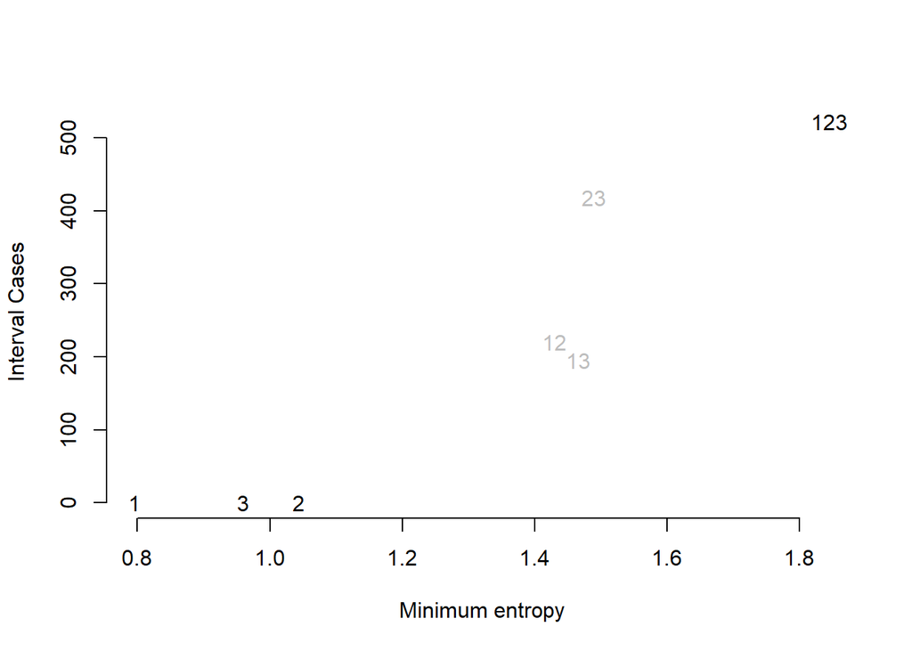

```r
plot(ent)
```

### Related functions: insert

The functions insert() and cpolr(), along with the method fitted() can be used directly in combination to produce the censored ordered probit histogram values,

[figure not shown]

```r
a1 <- anchors(fo, method = "C", data = freedom)
freedom2 <- insert(freedom, a1)
ca1 <- cpolr(cbind(Cs, Ce) ~ sex + age + educ + as.factor(country), data = freedom2)
ca1e <- fitted(ca1, a1e, Cvec = TRUE)
ca1o <- fitted(ca1, a1o, Cvec = TRUE)
barplot(rbind(ca1e, ca1o), main = "Minimum Entropy", beside = TRUE, xlab = "C")
```

The helper function insert() correctly combines the value of C found in a1 with the original data set. Specifically the two columns defining the range of C, Cs and Ce, are added to the data set while taking into account that cases may have been omitted when creating C.

Note that C is defined for all consecutive integers from 1 to 2J + 1, where J is the number of anchoring vignettes. If for a given data set, there are no observations that have a C value of any integer $j \in (1, ..., 2J + 1)$, then P($\hat C = j$) = 0 even if there are interval values of C that include j. Thus, cpolr() omits the cutpoint associated with missing scalar response categories, just as polr() would omit cutpoints for any missing response categories in the standard ordered probit.

In the function fitted(…,Cvec = TRUE) for cpolr objects this option requests the return of a 2J + 1 vector of the average probabilities for each of the ^ C categories (it simply does apply(…,1,mean) on the fitted matrix of probabilities). This summary vector is common enough a interest (as it is in this example) that it is simply incorporated into the function as an option.

# 5. Parametric Model

This section describes the Compound Hierarchical Ordered Probit (chopit) model.

The following section describes the implementation of general class of parametric models for analyzing survey responses with anchoring vignettes. Considerable exibility is provided in how to specify and identify the models so that users can easily make comparisons to different standard models of analyzing ordinal responses.

### Indexing notation

We index survey questions, response categories, and respondents as follows:

- we index vignette survey questions by $j$. One or more vignette questions are indicated by $j = 1,..., J_s$. In contrast to the non-parametric model, it is possible to have only a self-assessment for some respondents (indicated by $j$ = 0).
- we index response categories by $k (k = 1,..., K_s$) Each set of questions (self-assessment and vignettes) must have the same choice categories coded as increasing sequential integers starting with 1. Missing values (whether structural, because the question was not asked, or due to non-response) should be coded as $k = 0$.
- we index respondents by $i$. Respondent $i (i = 1,...,n$) may be asked a self-assessment question or vignette questions (or both). Indeed, any combination of questions is possible (e.g., asking $i$ all vignettes but no self evaluation; asking some vignettes and no self-evaluation, etc.) If an individual is not a question (self-evaluation or vignette) use the missing value code ($k = 0$), and this question will be dropped from the likelihood function.

Thus, every mathematical symbol in the model could be indexed by $j, k$, and $i$.

## 5.1. Self-assessment component.

Figure 1 summarizes the self-assessment component of the model. The actual level for respondent $i$ is $\mu_i$, a continuous unidimensional variable (with higher values indicating more freedom, better health, etc., defined by the order of the vignettes). Respondent i perceives $\mu_i$ only with random normal error so that

$$Y^*_{is} \sim N(\mu_i,
\sigma^2_{s})$$

is respondent $i$’s unobserved perceived level. The actual level is a linear function of observed covariates $X_i$, the first column of which can be a constant term (if it is not needed for identification) and an independent normal random effect $\eta_i$:

$$\mu_{i} = X_i\beta + \eta_i$$

with parameter $\beta$ and

$$\eta_i \sim N(0, \omega^2)$$

The reported survey response category is $y_{is}$ and is generated by the model via this observation mechanism:

$$y_{is} = k \quad \text{if}
\quad \tau^{k-1}_{is} \leq Y^*_{is} < \tau^k_{is}$$

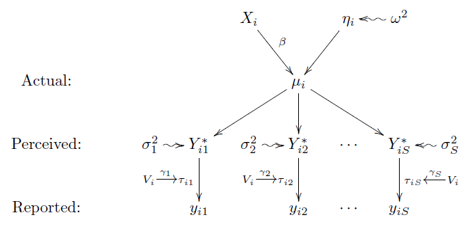

Figure 1. Self-Assessment Component: All levels vary over ob- servations i. Each solid arrow denotes a deterministic effect; a squiggly arrow denotes the addition of normal random error with variance indicated at the arrow’s source.

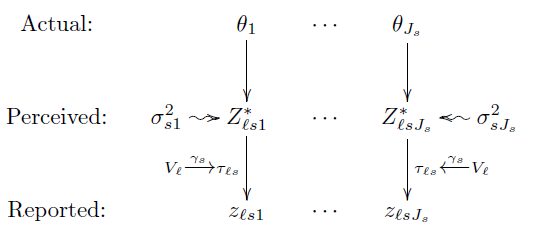

Fig2. Vignette Component

Figure 2. Vignette Component for question set $s$ ($s = 1,..., S', S' \leq S$). All levels vary over observations `. Each solid arrow de- notes a deterministic effect; a squiggly arrow denotes the addition of normal random error with variance indicated at the arrow’s source.

with a vector of thresholds $\tau_{is}$ (where $\tau_{is}^{0} = -\infty, \tau_{is}^{K_s} = \infty$ and $\tau_{is}^{k-1} < \tau_{is}^{k}$ with indexes for categories $k = 1,...,K_s$ and self-assessment questions $s = 1, ...,S$) that vary over the observations as a function of a vector of covariates, $V_i$ (the first column of which can be a constant term), and unknown parameter vectors $\gamma_s$(with elements the vector $\gamma_s^k$):

$$\tau^1_{is} = \gamma^1_{s}V_i$$
$$\tau^k_{is} = \tau^{k-1}_{is} +
e^{\gamma^k_{s}V_i}\quad (k=s,..,K_s -1)$$
## 5.2. Vignette Component.

Figure 2 summarizes the vignette component of the model for question set $s (s = 1,..., S)$. Under the model, one or more of the self-assessment questions have corresponding vignettes.

The actual level for vignette j is $\theta_j$ ($j = 1,..., J_s$), measured on the same scale as $\mu_i$ and the $\tau$’s. Respondent $l$ perceives $\theta_j$ with random normal error so that

$$Z^*_{lsj} \sim N(\theta_j,
\sigma^2_{sj})$$
represents respondent $l$’s unobserved assessment of the level of vignette $j$ for question set $s$.

The perception of respondent $l$ about the level of vignette $j$ elicited via a survey question $s$ with the same $K_s$ ordinal categories as the corresponding self-assessment question. Thus, the respondent turns the continuous $Z^*_{lsj}$ into a categorical answerto the survey question $Z_{lsj}$via this observation mechanism:

$$Z_{lsj} = k \quad \text{if}
\quad \tau^{k-1}_{ls} \leq Z^*_{lj} < \tau^k_{ls}$$

with thresholds determined by the same $\gamma_s$ coefficients as in (6) for $y_{i1}$, and the same explanatory variables but with values measured for units $l, V_l$:

$$\tau^1_{il} = \gamma^1_{s}V_l$$
$$\tau^k_{l1} = \tau^{k-1}_{ls} +
e^{\gamma^k_{s}V_l}\quad (k=s,..,K_1 -1)$$

## 5.3. Identification.

The model as specified above has an infinite number of equivalent maximum likelihood solutions. To identify the model, two choices must be made:

- 1. The mean of the actual level must be set, by choosing one point. This can be done by setting the constant term $\beta_0 = 0$ (in which case be aware of your choice of the scale of the variables in $X$), or one of the $\beta$’s.
- 2. The variance of the actual level must also be set. This can be done by setting all the self-assessment variances (such as $\sigma^2_{s} = 1$, for all $s$) or by setting another point among $\beta_0$ or the $\theta$’s.

Two common parameterizations are as follows:

- 1. The ordinal probit parameterization is useful for comparing chopit to this simpler model. Set $\beta_0 = 0$ and $\sigma^2_1 = ... = \sigma^2_s = 1$.
- 2. Another option is parameterization defined by the extreme vignettes. Let $\theta_1 = 0$ and $\theta_{Js} = 1$. This lets estimates of $\mu$ be interpreted on the scale of the vignettes, with 0 being the level of the lowest vignette and 1 the level of the highest. Note that $\mu$ can still be higher than 1 or lower than 0, but the units are easily interpretable.

## 5.4. Example Code: chopit().

The chopit() function provided by anchors at it’s most basic simply requires specifying the formula’s defining $y_s, z_s$, and $\tau$s. For example, using variables from the data(freedom) dataset, we have the named list.

```r
fo <- list(self = self ~ sex + age + educ + factor(country) ,
 vign = cbind(vign1,vign2,vign3,vign4,vign5,vign6) ~ 1 ,
 tau = ~ sex + age + educ + factor(country) )
```

The names self=, vign=, and tau= as written, are required. On the LHS of the equality signs are the variables of the dataset that specify the details of the models as for other models (e.g., lm()).

The self-assessment variable self is modeled to have a mean that is a linear additive function of sex, age, educ and country dummies. The vignettes are specified as a vector of outcomes cbind(vign1, vign2, vign3, vign4, vign5, vign6) as a function of only an intercept ‘$\sim$ 1’. This is both a simple and accurate way to describe the model of $\theta$s which are the mean locations of the vignettes. The $\tau$ cutpoints shared by the self-assessment and the vignettes are specified as their own formula without a LHS variable.

Beyond the formula and data, the rest will be set by default in the basic invocation,

```r
cout <- chopit(fo, data = freedom)
```

```
##
## chopit() will be identified/normalized by:
## 1. omitting the intercept in mu, (constant set to zero is beta.(Intercept) )
## 2. setting variance of first self question to 1
##
##
## NOTE: analytical gradients are being employed
##
```

The default invocation uses the the ordinal probit normalization, which identifies/normalizes the model by omitting the intercept in $\mu$, and setting $\sigma_1 = 1$ (the variance of the first self-assessment question). If one specified the explanatory variables of self= to include an intercept, then that intercept parameter would be constrained to be zero as will be beta.(Intercept) in this example.

The object cout contains the results of the analysis, and is of class chopit. The method summary() for chopit objects is useful for printing coefficients, log-likelihoods and related information. The likelihood is listed both overall, as well as for each component self-assessment and vignette.

which can be summarized by the summary method,

```r
summary(cout)
```

```
##
## ANCHORS: SUMMARY OF RELATIVE CHOPIT ANALYSIS:
##
## Model formula:
## $self
## self ~ sex + age + educ + factor(country)
##
## $vign
## cbind(vign1, vign2, vign3, vign4, vign5, vign6) ~ 1
##
## $tau
## ~sex + age + educ + factor(country)
##
## $cpolr
## ~1
## <environment: 0x0000021a10f5a270>
##
##
## Coefficients:
##                                     coeff     se
## gamma.cut1.(Intercept)            -1.6697 0.0774
## gamma.cut1.sex                     0.0570 0.0228
## gamma.cut1.age                    -0.0028 0.0007
## gamma.cut1.educ                    0.0109 0.0068
## gamma.cut1.factor(country)Eurasia  0.0447 0.0504
## gamma.cut1.factor(country)Oceania -0.1262 0.0309
## gamma.cut2.(Intercept)             0.6655 0.0388
## gamma.cut2.sex                    -0.0426 0.0205
## gamma.cut2.age                     0.0013 0.0006
## gamma.cut2.educ                   -0.0140 0.0061
## gamma.cut2.factor(country)Eurasia -0.0286 0.0449
## gamma.cut2.factor(country)Oceania  0.0260 0.0274
## gamma.cut3.(Intercept)             0.7068 0.0319
## gamma.cut3.sex                    -0.0211 0.0167
## gamma.cut3.age                    -0.0001 0.0005
## gamma.cut3.educ                    0.0112 0.0051
## gamma.cut3.factor(country)Eurasia  0.0250 0.0374
## gamma.cut3.factor(country)Oceania -0.0985 0.0218
## gamma.cut4.(Intercept)             0.5937 0.0294
## gamma.cut4.sex                     0.0436 0.0159
```

[output cut: 25 more lines]

```
## -Log-likelihood of CHOPIT:  32421.69
##
## Partition of CHOPIT -Log-likelihood by question:
##                  -LL    N
## Self (self) 5154.965 3447
## vign1       5032.314 3447
## vign2       5207.052 3447
## vign3       4766.234 3447
## vign4       4340.710 3447
## vign5       4485.543 3447
## vign6       3434.877 3447
##
## Number of cases that contribute at least partially to likelihoods:
##    a) in self-responses: 3447
##    b) in vign-responses: 3447
```

Note that parameters fixed by identification restrictions are shown but have their standard errors (chopit.se) listed as NaN. The naming convention of the parameters is as follows. First there are the gamma ( ) parameters. Among the entire set of gamma parameters, the set of parameters associated with each cutpoint are grouped by the second appended label (cut1, cut2, etc), and the names of the covariates appended last (e.g., age, educ). Next, there the standard deviations of the normal distributions in the model: the row sigma.self represents $\sigma$; sigma.vign1 represents $\sigma_1$, etc. Similarly, theta.vign1 represents the mean location of the first vignette, theta.vign2 represents the mean locating of the second vignette, etc. Finally, the beta rows represent the parameters associated with estimating the location of self-evaluations.

## 5.5. Identification

The parameters of the model requires identification restrictions:

- 1. The location on the actual (latent) scale must be chosen. This can be done by setting the intercept of the self-evaluation equations to a fixed value ($\beta_0 = 0$ matches the convention of ordered probits) or one of the $\theta$’s.
- 2. The scale of the actual (latent) level must also be chosen. This can be done by setting the self-assessment variance to a fixed value values ($\sigma^2 = 1$ matches the convention of ordered probits) or by setting another $\theta$’s.

Two common parameterizations are as follows:

- As noted, the ordinal probit parameterization is useful for comparing chopit to this simpler model. Set $\beta_0 = 0$ and $\sigma^2 = 1$. This is the default, and no action is needed by the user.
- Note: the variances of the vignettes are estimated under this default normalization. To further constrain the variances of the vignette stochastic terms $\sigma^2_j$ to also be equal to 1, use the option
- R> chopit(fo, freedom, options = anchors.options(single.vign.var = TRUE))
- 2. Another option is parameterization defined by the extreme vignettes. Let $\theta_1 = 0$ and $\theta_J = 1$. This lets estimates of $\mu$ be interpreted on the scale of the vignettes, with 0 being the level of the lowest vignette and 1 the level of the highest. Note that $\mu$ can still be higher than 1 or lower than 0.
- To identify the model by setting $\theta_1 = 0$ and $\theta_J = 1$, use the option

R> chopit(fo, freedom, options = anchors.options(normalize = “hilo”))

- Caution: The order of the vignettes does matter for this normalization. If you constrain the $\=theta$ parameters to have an order different from what would be estimated without constraints, odd results such as extremely large standard errors and implausibly large parameter estimates can occur. $Hint$: if in doubt, use the normalize = “self” model first to establish the order of the vignettes

## 5.6. Additional options

There are a variety of options, among which the following are the most often used,

- Instead of the default optimizer optim(), use genoud() (Mebane and Sekhon 2009a,b): e.g.,

```r
cout2 <- chopit(fo, freedom,
                options = anchors.options(optimizer = "genoud",
                                          start = cout$parm,
                                          print.level = 1))
```

[output not shown]

[output cut: 87 more lines]

```
##  X[33] : -2.478105e-01   G[33] : 3.459948e-06
##  X[34] : 1.660390e-01    G[34] : -2.310742e-06
##  X[35] : -5.617178e-02   G[35] : -5.377165e-06
##  X[36] : 9.518774e-01    G[36] : 1.989875e-06
##  X[37] : 1.434137e-01    G[37] : -1.844128e-07
##  X[38] : -1.943766e-03   G[38] : -8.651596e-06
##  X[39] : -5.687938e-02   G[39] : -2.849202e-06
##  X[40] : 4.600477e-01    G[40] : -3.485366e-07
##  X[41] : -7.018777e-01   G[41] : 2.357848e-08
##
## Solution Found Generation 1
## Number of Generations Run 2
##
## Tue Jan 14 14:58:04 2025
## Total run time : 0 hours 0 minutes and 3 seconds
```

As there is as yet no proof of the global concavity of the chopit likelihood, a prudent researcher should investigate whether a choit model fitted using optim() is potentially at a local maximum rather than the global maximum of likelihood. Genoud does not rely on global concavity of the likelihood, and is an efficient approach to finding the global maximum.

- The option use.gr toggles whether or not to use the analytical gradients that have been derived for the model with a linear parameterization of cutpoints. If use.gr = TRUE then analytical gradients are used. The use of numerical gradients via use.gr = FALSE, which is currently required if $\tau$ are specified as non-linear function, is significantly more time consuming to estimate.
- See help(“chopit”) and demo(“chopit”) for additional examples of options.

### C_MinEnt

```r
freedom2$C_minent <- (freedom2$Ce + freedom2$Cs)/2
table(freedom2$self, freedom2$C_minent)
```

```
##
##       1   2 2.5   3 3.5   4 4.5   5 5.5   6   7
##   1 227  56   4   1   3   5   0   0   0   0   0
##   2 181  80   6 136  13  13   1  17   0   1   4
##   3  66  76   7 289  15 151  12  93   7  10  36
##   4  22  13   5 106   7 155  22 442  11  57 155
##   5   0   0   0   0   0  48   5 147  26 421 295
```

# 6. Manual

## 6.1. Insert DIF-corrected variable into original data frame

```r
data(freedom)
ra <- anchors(self ~ vign1 + vign3 + vign6, data = freedom, method="B")
freedom3 <- insert(freedom, ra )
names(freedom)
```

```
##  [1] "sex"     "age"     "educ"    "country" "self"    "vign1"   "vign2"
##  [8] "vign3"   "vign4"   "vign5"   "vign6"
```

# 7. Reference

- https://blog.naver.com/smileaddict/222569930575